# Peer-graded Assignment: Prediction Assignment Writeup

##### Hasitha Ranawaka, 20 October 2019

### Introduction

Using devices such as Jawbone Up, Nike FuelBand, and Fitbit it is now possible to collect a large amount of data about personal activity relatively inexpensively. These type of devices are part of the quantified self movement – a group of enthusiasts who take measurements about themselves regularly to improve their health, to find patterns in their behavior, or because they are tech geeks. One thing that people regularly do is quantify how much of a particular activity they do, but they rarely quantify how well they do it. In this project, the goal is to use data from accelerometers on the belt, forearm, arm, and dumbell of 6 participants. They were asked to perform barbell lifts correctly and incorrectly in 5 different ways.

### Data Processing

##### Loading required R packages

```r
set.seed(5)
library(dplyr)
```

```r
library(ggplot2)
library(caret)
```

#### Loading data into R

```r
filename_test <- "pml-testing.csv."
filename_train <- "pml-training.csv"

# checking whether the files exist
if (!file.exists(filename_test)){
        fileURL <- "https://d396qusza40orc.cloudfront.net/predmachlearn/pml-testing.csv"
        download.file(fileURL, filename)
}

if (!file.exists(filename_train)){
        fileURL <- "https://d396qusza40orc.cloudfront.net/predmachlearn/pml-training.csv"
        download.file(fileURL, filename)
}

# Loading data into R
training = read.csv("./pml-training.csv",na.strings=c("NA","#DIV/0!",""))
testing = read.csv("./pml-testing.csv",na.strings=c("NA","#DIV/0!",""))
```

#### Cleaning data

Removing NAs

```r
training <- training[, which(colSums(is.na(training)) == 0)]
testing <- testing[, which(colSums(is.na(testing)) == 0)]
```

Removing unnecessary first few columns

```r
training <- training[,-(1:7)]
testing <- testing[,-(1:7)]
```

### Creating crossvalidation datasets

```r
inTrain <- createDataPartition(training$classe, p=0.70, list=FALSE)
train <- training[inTrain, ]
test <- training[-inTrain, ]
```

### Modelling

#### Modelling with regression trees

```r
fit_regtr <- train(classe ~ ., method="rpart", data=train)
pred_regtr <- predict(fit_regtr, test)
confMat_regtr = confusionMatrix(test$classe, pred_regtr)
confMat_regtr
```

```
## Confusion Matrix and Statistics
##
##           Reference
## Prediction    A    B    C    D    E
##          A 1531   25  111    0    7
##          B  491  376  272    0    0
##          C  466   28  532    0    0
##          D  424  177  363    0    0
##          E  175  151  276    0  480
##
## Overall Statistics
##
##                Accuracy : 0.496
##                  95% CI : (0.4832, 0.5089)
##     No Information Rate : 0.5246
##     P-Value [Acc > NIR] : 1
##
##                   Kappa : 0.3409
##
##  Mcnemar's Test P-Value : NA
##
## Statistics by Class:
##
##                      Class: A Class: B Class: C Class: D Class: E
## Sensitivity            0.4960  0.49670   0.3423       NA  0.98563
## Specificity            0.9489  0.85121   0.8859   0.8362  0.88848
## Pos Pred Value         0.9146  0.33011   0.5185       NA  0.44362
## Neg Pred Value         0.6305  0.91972   0.7897       NA  0.99854
## Prevalence             0.5246  0.12863   0.2641   0.0000  0.08275
## Detection Rate         0.2602  0.06389   0.0904   0.0000  0.08156
## Detection Prevalence   0.2845  0.19354   0.1743   0.1638  0.18386
## Balanced Accuracy      0.7224  0.67395   0.6141       NA  0.93705
```

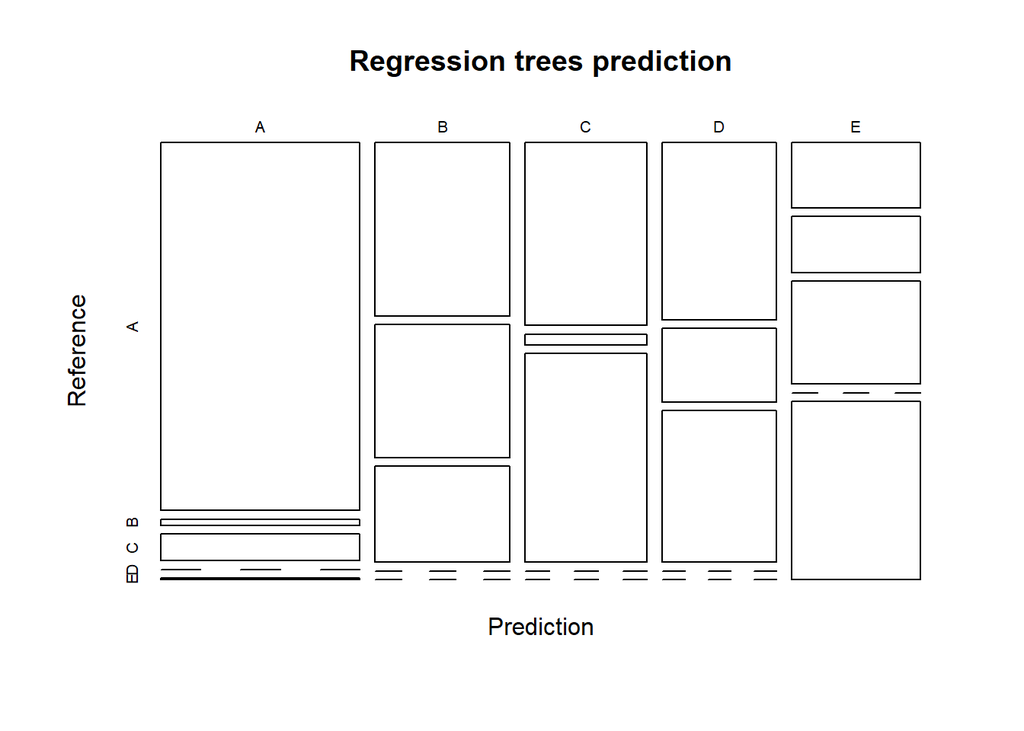

```r
plot(confMat_regtr$table, col = confMat_regtr$byClass,
     main = "Regression trees prediction")
```

#### Modelling with random forest

```r
fit_ranfor <- train(classe ~ ., method="rf", data=train, ntree =10 )
pred_ranfor <- predict(fit_ranfor, test)
confMat_ranfor = confusionMatrix(test$classe, pred_ranfor)
confMat_ranfor
```

```
## Confusion Matrix and Statistics
##
##           Reference
## Prediction    A    B    C    D    E
##          A 1668    4    2    0    0
##          B   13 1116    7    1    2
##          C    0    8 1015    3    0
##          D    0    1   15  948    0
##          E    0    2    2    4 1074
##
## Overall Statistics
##
##                Accuracy : 0.9891
##                  95% CI : (0.9861, 0.9916)
##     No Information Rate : 0.2856
##     P-Value [Acc > NIR] : < 2.2e-16
##
##                   Kappa : 0.9862
##
##  Mcnemar's Test P-Value : NA
##
## Statistics by Class:
##
##                      Class: A Class: B Class: C Class: D Class: E
## Sensitivity            0.9923   0.9867   0.9750   0.9916   0.9981
## Specificity            0.9986   0.9952   0.9977   0.9968   0.9983
## Pos Pred Value         0.9964   0.9798   0.9893   0.9834   0.9926
## Neg Pred Value         0.9969   0.9968   0.9946   0.9984   0.9996
## Prevalence             0.2856   0.1922   0.1769   0.1624   0.1828
## Detection Rate         0.2834   0.1896   0.1725   0.1611   0.1825
## Detection Prevalence   0.2845   0.1935   0.1743   0.1638   0.1839
## Balanced Accuracy      0.9954   0.9909   0.9864   0.9942   0.9982
```

Here the accuray is very good with a value of 0.9891

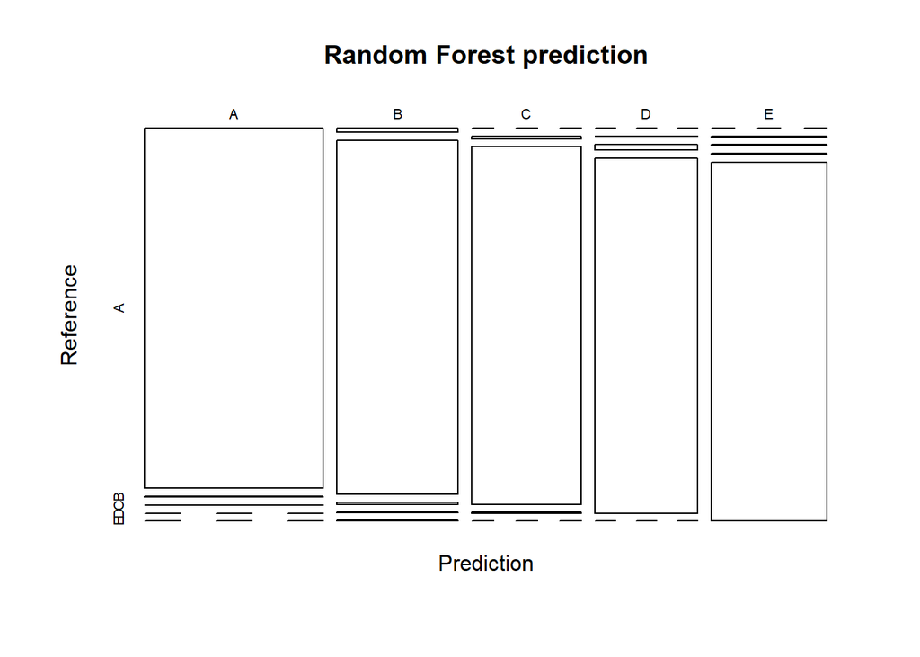

```r
plot(confMat_ranfor$table, col = confMat_ranfor$byClass,
     main = "Random Forest prediction")
```

### Conclusion

FOr this particular dataset modelling with random forests is suitable.